# Deer Reproduction & Disease Control: Statistical Analyses (part 2)

*Damian Satterthwaite-Phillips*

### Pregnancy Rates

First though, we examine the relationship between pairs of variables to alert us to potential non-linear relationships.

First though, to make things simple, reorder age, so that the levels are in ascending order of age.

```r
levels(deerF1$age)
```

[output not shown]

```r
deerF1$age = factor(deerF1$age, levels = c('fawn', 'yearling', 'adult'))
levels(deerF1$age)
```

```
## [1] "fawn"     "yearling" "adult"
```

Also, we want to use the year variable to correct for stochastic/random variation from one year to the next. (This might actually be a proxy for many other things like temperature, rainfall, food supply, etc. that we do not have in our data set, but that nevertheless cause annual variations.) Hence, it may be better to treat year as a categorical variable rather than a continous one, though we will compare both models.

```r
deerF1$yearF = as.factor(deerF1$year)
```

Now on to comparing pairs of variables.

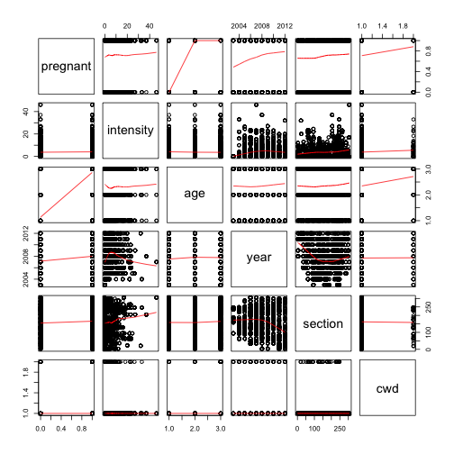

```r
modVars = deerF1[, c('pregnant', 'intensity', 'age', 'year', 'section',
                     'cwd')]
pairs(modVars, panel = panel.smooth)
```

Intensity, age, and year all look like they may potentially have non-linear relationships with some of the other variables, so to potentially capture this in the model, we will include their squared terms as predictors as well.

```r
preg.glm.fullc = glm(pregnant ~ (intensity + I(intensity^2) + age +
                     year + I(year^2) + cwd)^2 + section - intensity:I(intensity^2),
                     data = deerF1)
preg.glm.redc = step(preg.glm.fullc, direction = 'both', trace = 0)
summary(preg.glm.redc) # AIC: 3296.5 # dev. ex: 47.36%
```

```
##
## Call:
## glm(formula = pregnant ~ I(intensity^2) + age + year + I(year^2) +
##     cwd + section + I(intensity^2):cwd + age:year + age:I(year^2) +
##     year:I(year^2), data = deerF1)
##
## Deviance Residuals:
##      Min        1Q    Median        3Q       Max
## -1.08287  -0.17124   0.06057   0.17018   1.03212
##
## Coefficients:
##                         Estimate Std. Error t value Pr(>|t|)
## (Intercept)           -1.947e+07  4.205e+06  -4.630 3.79e-06 ***
## I(intensity^2)         1.128e-04  4.376e-05   2.578 0.009984 **
## ageyearling           -4.233e+04  1.244e+04  -3.403 0.000674 ***
## ageadult              -3.248e+04  8.961e+03  -3.625 0.000293 ***
## year                   2.909e+04  6.284e+03   4.630 3.79e-06 ***
## I(year^2)             -1.449e+01  3.130e+00  -4.630 3.79e-06 ***
## cwdpos                -1.502e-02  5.319e-02  -0.282 0.777646
## section333N5E14       -2.081e-01  1.922e-01  -1.083 0.279034
## section333N5E15       -1.362e-01  1.797e-01  -0.758 0.448526
## section333N5E17        5.846e-02  1.840e-01   0.318 0.750789
## ...other sections omitted for brevity...
## I(intensity^2):cwdpos  4.187e-04  2.451e-04   1.708 0.087738 .
## ageyearling:year       4.212e+01  1.239e+01   3.400 0.000681 ***
## ageadult:year          3.234e+01  8.927e+00   3.622 0.000296 ***
## ageyearling:I(year^2) -1.048e-02  3.085e-03  -3.397 0.000689 ***
## ageadult:I(year^2)    -8.048e-03  2.223e-03  -3.620 0.000299 ***
## year:I(year^2)         2.406e-03  5.197e-04   4.630 3.79e-06 ***
## ---
## Signif. codes:  0 '***' 0.001 '**' 0.01 '*' 0.05 '.' 0.1 ' ' 1
##
## (Dispersion parameter for gaussian family taken to be 0.1300395)
##
##     Null deviance: 850.97  on 3755  degrees of freedom
## Residual deviance: 447.99  on 3445  degrees of freedom
##   (23 observations deleted due to missingness)
## AIC: 3296.5
##
## Number of Fisher Scoring iterations: 2
```

```r
preg.glm.fullf = glm(pregnant ~ (intensity + I(intensity^2) + age +
                     yearF + cwd)^2 + section - intensity:I(intensity^2),
                     data = deerF1)
preg.glm.redf = step(preg.glm.fullf, direction = 'both', trace = 0)
summary(preg.glm.redf) # AIC: 3247.8 # dev.ex = 48.59
```

```
##
## Call:
## glm(formula = pregnant ~ I(intensity^2) + age + yearF + cwd +
##     section + I(intensity^2):cwd + age:yearF, data = deerF1)
##
## Deviance Residuals:
##      Min        1Q    Median        3Q       Max
## -1.14044  -0.16362   0.05093   0.17365   1.09275
##
## Coefficients:
##                         Estimate Std. Error t value Pr(>|t|)
## (Intercept)            1.747e-01  1.745e-01   1.001 0.316811
## I(intensity^2)         6.981e-05  4.465e-05   1.563 0.118075
## ageyearling            6.362e-02  1.105e-01   0.576 0.564914
## ageadult               3.201e-01  7.269e-02   4.404 1.10e-05 ***
## yearF2004              1.808e-01  7.553e-02   2.394 0.016721 *
## yearF2005              1.426e-01  7.572e-02   1.884 0.059692 .
## yearF2006              8.817e-02  7.466e-02   1.181 0.237704
## yearF2007              1.549e-01  7.200e-02   2.151 0.031557 *
## yearF2008              1.547e-01  7.298e-02   2.119 0.034133 *
## yearF2009              1.143e-01  7.793e-02   1.467 0.142389
## yearF2010              1.322e-01  7.900e-02   1.674 0.094248 .
## yearF2011              1.685e-02  7.666e-02   0.220 0.826041
## yearF2012              3.103e-01  8.498e-02   3.651 0.000265 ***
## cwdpos                -4.686e-03  5.284e-02  -0.089 0.929334
## section333N5E14       -2.211e-01  1.910e-01  -1.158 0.246978
## section333N5E15       -1.574e-01  1.785e-01  -0.881 0.378127
## section333N5E17        3.710e-02  1.834e-01   0.202 0.839702
## ...other sections omitted for brevity...
## I(intensity^2):cwdpos  3.583e-04  2.441e-04   1.468 0.142252
## ageyearling:yearF2004  2.448e-01  1.266e-01   1.933 0.053324 .
## ageadult:yearF2004     2.299e-01  8.560e-02   2.686 0.007275 **
## ageyearling:yearF2005  5.181e-01  1.330e-01   3.896 9.95e-05 ***
## ageadult:yearF2005     3.214e-01  8.627e-02   3.726 0.000198 ***
## ageyearling:yearF2006  6.024e-01  1.258e-01   4.789 1.75e-06 ***
## ageadult:yearF2006     3.923e-01  8.286e-02   4.734 2.29e-06 ***
## ageyearling:yearF2007  4.135e-01  1.214e-01   3.405 0.000669 ***
## ageadult:yearF2007     2.456e-01  8.060e-02   3.047 0.002327 **
## ageyearling:yearF2008  5.561e-01  1.216e-01   4.575 4.94e-06 ***
## ageadult:yearF2008     3.791e-01  8.104e-02   4.678 3.00e-06 ***
## ageyearling:yearF2009  5.302e-01  1.300e-01   4.078 4.65e-05 ***
## ageadult:yearF2009     3.815e-01  8.595e-02   4.438 9.35e-06 ***
## ageyearling:yearF2010  5.942e-01  1.318e-01   4.507 6.78e-06 ***
## ageadult:yearF2010     4.019e-01  8.886e-02   4.523 6.30e-06 ***
## ageyearling:yearF2011  6.638e-01  1.250e-01   5.308 1.18e-07 ***
## ageadult:yearF2011     4.764e-01  8.361e-02   5.698 1.31e-08 ***
## ageyearling:yearF2012  4.487e-01  1.316e-01   3.410 0.000656 ***
## ageadult:yearF2012     1.717e-01  9.240e-02   1.858 0.063265 .
## ---
## Signif. codes:  0 '***' 0.001 '**' 0.01 '*' 0.05 '.' 0.1 ' ' 1
##
## (Dispersion parameter for gaussian family taken to be 0.1277444)
##
##     Null deviance: 850.97  on 3755  degrees of freedom
## Residual deviance: 437.52  on 3425  degrees of freedom
##   (23 observations deleted due to missingness)
## AIC: 3247.8
##
## Number of Fisher Scoring iterations: 2
```

This model is somewhat better by the AIC (3247.8), as well as explaining more of the deviance.

The reduced model suggests that sharpshooting intensity does not have a significant affect on pregnancy. There are signifcant differences in pregnancy by year, and the age of the mother (as we would expect), and there are significant differences by location as well. Before exploring this further, we first examine the model diagnostics.

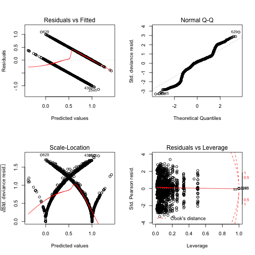

```r
par(mfrow = c(2, 2))
plot(preg.glm.redf)
```

Recalling that the response is a binary variable, these diagnostics are mostly not too bad, though the last plot above does indicate several points that have a very high leverage, and may be exerting disproportionate influence on the model. Look at these:

```r
cooks.d = cooks.distance(preg.glm.redf)
inf = which(is.nan(cooks.d))
modVars[inf, ]
```

```
##      pregnant intensity      age year   section cwd
## 133         1         1 yearling 2012   333N6E8 neg
## 2958        1         0    adult 2006  346N5E32 neg
## 3015        1         0    adult 2009   344N6E1 neg
## 3171        0         0    adult 2007 427N10E17 neg
## 3243        1         0 yearling 2004   344N7E2 neg
## 3489        0         0     fawn 2004  346N2E24 neg
## 3575        0         0     fawn 2007  423N10E8 neg
## 3909        1         0    adult 2012   338N7E9 neg
## 3931        0         0    adult 2006  340N10E7 neg
## 3942        0         0    adult 2006  340N9E23 neg
## 3948        1         0    adult 2006   341N1E7 neg
## 4239        1         0 yearling 2004  344N4E29 neg
## 4308        1         0     fawn 2004  344N8E17 neg
## 4329        0         0    adult 2003  345N2E23 neg
## 4609        0         0     fawn 2011  425N11E1 neg
## 4666        0         0     fawn 2005  427N11E5 neg
## 4693        1         0    adult 2008  427N6E26 neg
```

All points appear to have 0 or one intensity values, but considering that there are…

```r
sum(deerF1$intensity == 0 | deerF1$intensity == 1, na.rm = T)
```

```
## [1] 1741
```

```r
preg.glm.fulli = glm(pregnant ~ (intensity + I(intensity^2) + age +
                     yearF + cwd)^2 + section - intensity:I(intensity^2),
                     data = deerF1[-inf, ])
preg.glm.redi = step(preg.glm.fulli, direction = 'both', trace = 0)
summary(preg.glm.redi)
```

```
##
## Call:
## glm(formula = pregnant ~ I(intensity^2) + age + yearF + cwd +
##     section + I(intensity^2):cwd + age:yearF, data = deerF1[-inf,
##     ])
##
## Deviance Residuals:
##      Min        1Q    Median        3Q       Max
## -1.13896  -0.16436   0.05225   0.17135   1.09302
##
## Coefficients:
##                         Estimate Std. Error t value Pr(>|t|)
## (Intercept)            1.781e-01  1.747e-01   1.020 0.307915
## I(intensity^2)         7.284e-05  4.472e-05   1.629 0.103492
## ageyearling            6.294e-02  1.106e-01   0.569 0.569329
## ageadult               3.265e-01  7.286e-02   4.481 7.68e-06 ***
## yearF2004              1.795e-01  7.577e-02   2.369 0.017872 *
## yearF2005              1.391e-01  7.581e-02   1.835 0.066603 .
## yearF2006              8.554e-02  7.474e-02   1.145 0.252485
## yearF2007              1.527e-01  7.210e-02   2.118 0.034271 *
## yearF2008              1.504e-01  7.309e-02   2.057 0.039742 *
## yearF2009              1.089e-01  7.807e-02   1.394 0.163339
## yearF2010              1.286e-01  7.910e-02   1.626 0.104105
## yearF2011              1.406e-02  7.681e-02   0.183 0.854813
## yearF2012              3.067e-01  8.508e-02   3.605 0.000316 ***
## cwdpos                -4.823e-03  5.288e-02  -0.091 0.927323
## section333N5E14       -2.205e-01  1.911e-01  -1.154 0.248626
## section333N5E15       -1.567e-01  1.787e-01  -0.877 0.380379
## section333N5E17        3.773e-02  1.835e-01   0.206 0.837162
## ...other sections omitted for brevity...
## I(intensity^2):cwdpos  3.579e-04  2.443e-04   1.465 0.143047
## ageyearling:yearF2004  2.327e-01  1.273e-01   1.828 0.067596 .
## ageadult:yearF2004     2.263e-01  8.592e-02   2.634 0.008484 **
## ageyearling:yearF2005  5.196e-01  1.331e-01   3.905 9.60e-05 ***
## ageadult:yearF2005     3.177e-01  8.647e-02   3.674 0.000243 ***
## ageyearling:yearF2006  6.032e-01  1.259e-01   4.790 1.74e-06 ***
## ageadult:yearF2006     3.858e-01  8.306e-02   4.645 3.52e-06 ***
## ageyearling:yearF2007  4.135e-01  1.215e-01   3.402 0.000677 ***
## ageadult:yearF2007     2.397e-01  8.081e-02   2.966 0.003040 **
## ageyearling:yearF2008  5.577e-01  1.216e-01   4.584 4.72e-06 ***
## ageadult:yearF2008     3.719e-01  8.119e-02   4.580 4.82e-06 ***
## ageyearling:yearF2009  5.326e-01  1.301e-01   4.093 4.36e-05 ***
## ageadult:yearF2009     3.758e-01  8.615e-02   4.362 1.33e-05 ***
## ageyearling:yearF2010  5.952e-01  1.319e-01   4.512 6.65e-06 ***
## ageadult:yearF2010     3.955e-01  8.902e-02   4.443 9.15e-06 ***
## ageyearling:yearF2011  6.638e-01  1.252e-01   5.303 1.21e-07 ***
## ageadult:yearF2011     4.693e-01  8.387e-02   5.596 2.37e-08 ***
## ageyearling:yearF2012  4.493e-01  1.317e-01   3.412 0.000652 ***
## ageadult:yearF2012     1.649e-01  9.258e-02   1.781 0.074932 .
## ---
## Signif. codes:  0 '***' 0.001 '**' 0.01 '*' 0.05 '.' 0.1 ' ' 1
##
## (Dispersion parameter for gaussian family taken to be 0.1279287)
##
##     Null deviance: 846.48  on 3738  degrees of freedom
## Residual deviance: 436.11  on 3409  degrees of freedom
##   (23 observations deleted due to missingness)
## AIC: 3238.9
##
## Number of Fisher Scoring iterations: 2
```

Using the last model, we will visualize the effects of intensity and age of the mother on pregnancy. We will look at these for the 'typical' year and location by using the year and section with the median coefficient in the model.

```r
# median coef for year
yrCoef = median(c(0, coef(preg.glm.redi)[5:13])) # nearest to 2005 and 2010
sectCoef = median(c(0, coef(preg.glm.redi)[15:311])) # near 334N4E1
yrlYrCoef = median(c(0, coef(preg.glm.redi)[seq(313, 329, 2)]))
adYrCoef = median(c(0, coef(preg.glm.redi)[seq(314, 330, 2)]))
```

In R, we can use the predict function to obtain the fitted values or observe predicted values for new data. Our range of intensity values is:

```r
range(deerF1$intensity, na.rm = T)
```

```
## [1]  0 46
```

…so we set

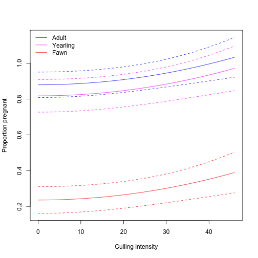

```r
int = seq(min(deerF1$intensity, na.rm = T), max(deerF1$intensity, na.rm = T),
          length = 100)

newdata = data.frame(
    intensity = int,
    age = c(rep('fawn', 100), rep('yearling', 100), rep('adult', 100)),
    yearF = '2005',
    cwd = 'neg',
    section = '334N4E1'
)

glm.pred = predict(preg.glm.redi, newdata = newdata, type = 'response', se.fit = T,
                   interval = 'confidence', level = 0.95)
par(mfrow = c(1, 1))
plot(glm.pred$fit[1:100] ~ int, type = 'l', col = 2,
     ylim = c(min(glm.pred$fit - glm.pred$se.fit),
              max(glm.pred$fit + glm.pred$se.fit)),
     xlab = 'Culling intensity', ylab = 'Proportion pregnant')
lines(glm.pred$fit[1:100] - glm.pred$se.fit[1:100] ~ int, col = 2, lty = 2)
lines(glm.pred$fit[1:100] + glm.pred$se.fit[1:100] ~ int, col = 2, lty = 2)
lines(glm.pred$fit[101:200] ~ int, col = 6)
lines(glm.pred$fit[101:200] - glm.pred$se.fit[101:200] ~ int,
      col = 6, lty = 2)
lines(glm.pred$fit[101:200] + glm.pred$se.fit[101:200] ~ int,
      col = 6, lty = 2)
lines(glm.pred$fit[201:300] ~ int, col = 4)
lines(glm.pred$fit[201:300] - glm.pred$se.fit[201:300] ~ int,
      col = 4, lty = 2)
lines(glm.pred$fit[201:300] + glm.pred$se.fit[201:300] ~ int,
      col = 4, lty = 2)
legend('topleft', lty = 1, col = c(4, 6, 2),
       legend = c('Adult', 'Yearling', 'Fawn'), bty = 'n')
```

This is a reasonably well-fitting model, but as one last approach, I attempt a non-parametric fit using a generalized additive model that approximates the functions for each variable using a nonparametric apporoach (e.g., splines or kernel density methods).

```r
library(mgcv)
preg.gam = gam(pregnant ~ s(intensity) + (age + yearF + cwd)^2 +
               intensity:cwd + intensity:age + intensity:yearF + section,
               scale = -1,
               family = 'binomial', data = deerF1)
summary(preg.gam)
```

```
##
## Family: binomial
## Link function: logit
##
## Formula:
## pregnant ~ s(intensity) + (age + yearF + cwd)^2 + intensity:cwd +
##     intensity:age + intensity:yearF + section
##
## Parametric coefficients:
##                         Estimate Std. Error t value Pr(>|t|)
## (Intercept)           -1.161e+00  2.159e+00  -0.538 0.590877
## ageyearling            6.581e-01  1.002e+00   0.657 0.511287
## ageadult               2.237e+00  7.229e-01   3.094 0.001989 **
## yearF2004              1.553e+00  7.682e-01   2.021 0.043317 *
## yearF2005              1.312e+00  8.294e-01   1.582 0.113708
## yearF2006              1.338e+00  8.301e-01   1.612 0.107157
## yearF2007              1.114e+00  7.896e-01   1.411 0.158465
## yearF2008              1.253e+00  8.114e-01   1.545 0.122547
## yearF2009              1.246e+00  8.676e-01   1.436 0.151228
## yearF2010              1.667e+00  9.470e-01   1.761 0.078406 .
## yearF2011              7.626e-02  9.260e-01   0.082 0.934371
## yearF2012              2.305e+00  9.678e-01   2.382 0.017284 *
## cwdpos                -5.351e+00  4.233e+00  -1.264 0.206298
## section333N5E14       -2.445e+00  2.155e+00  -1.134 0.256719
## section333N5E15       -1.789e+00  2.114e+00  -0.847 0.397316
## section333N5E17        3.788e-01  2.187e+00   0.173 0.862502
## ...other sections omitted for brevity...
## ageyearling:yearF2004  9.262e-01  1.091e+00   0.849 0.396106
## ageadult:yearF2004     6.678e-01  8.033e-01   0.831 0.405866
## ageyearling:yearF2005  2.444e+00  1.182e+00   2.067 0.038777 *
## ageadult:yearF2005     1.569e+00  8.466e-01   1.853 0.063936 .
## ageyearling:yearF2006  2.850e+00  1.150e+00   2.477 0.013292 *
## ageadult:yearF2006     1.893e+00  8.224e-01   2.302 0.021419 *
## ageyearling:yearF2007  1.732e+00  1.078e+00   1.607 0.108137
## ageadult:yearF2007     7.866e-01  7.819e-01   1.006 0.314457
## ageyearling:yearF2008  2.718e+00  1.106e+00   2.458 0.014026 *
## ageadult:yearF2008     2.316e+00  8.214e-01   2.820 0.004837 **
## ageyearling:yearF2009  2.581e+00  1.185e+00   2.177 0.029514 *
## ageadult:yearF2009     2.298e+00  8.668e-01   2.651 0.008056 **
## ageyearling:yearF2010  2.940e+00  1.224e+00   2.403 0.016320 *
```

[output cut: 24 more lines]

```
## yearF2008:intensity    2.399e-02  5.906e-02   0.406 0.684570
## yearF2009:intensity   -1.862e-02  6.140e-02  -0.303 0.761649
## yearF2010:intensity   -2.532e-02  6.968e-02  -0.363 0.716346
## yearF2011:intensity    0.000e+00  0.000e+00      NA       NA
## yearF2012:intensity    4.778e-02  8.009e-02   0.597 0.550797
## ---
## Signif. codes:  0 '***' 0.001 '**' 0.01 '*' 0.05 '.' 0.1 ' ' 1
##
## Approximate significance of smooth terms:
##                edf Ref.df     F p-value
## s(intensity) 2.992  3.955 1.582   0.155
##
## Rank: 360/362
## R-sq.(adj) =  0.458   Deviance explained =   44%
## GCV = 0.88254  Scale est. = 1.1044    n = 3756
```

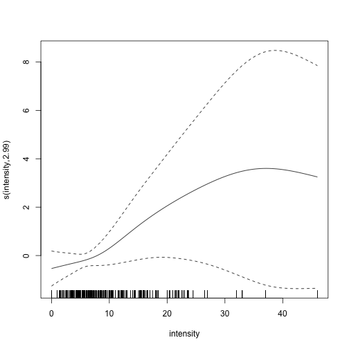

```r
plot(preg.gam)
```

As with the glm, I reduce the model in a stepwise fashion. Since AIC here is approximate, the step() function will not work, so I simply did it by hand. Rejected steps have been omitted here for brevity.

```r
AIC(preg.gam) #3427.831
```

```
## [1] 3427.831
```

```r
preg.gam2 = update(preg.gam, .~. -section)
AIC(preg.gam2) # 3370.641
```

```
## [1] 3370.641
```

```r
preg.gam3 = update(preg.gam2, .~. -yearF:cwd)
AIC(preg.gam3) # 3366.442
```

```
## [1] 3366.442
```

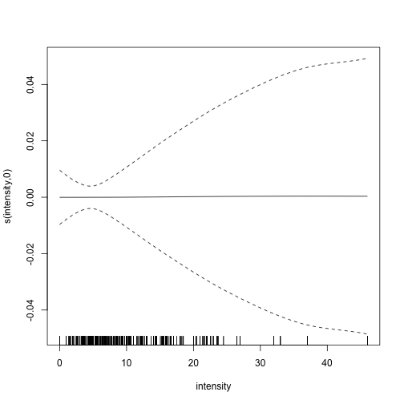

```r
plot(preg.gam3)
```

```r
# As the "smoothed" intensity parameter is now flat, revert to a glm with the same
# parameters, replacing intensity with a parametric predictor.
preg.glm4 = glm(pregnant ~ intensity + age + yearF + cwd + age:yearF + age:cwd +
                cwd:intensity + age:intensity + yearF:intensity,
                family = 'binomial', data = deerF1)
prg.glm.final = step(preg.glm4, direction = 'both', trace = 0)
```

```
## Error in step(preg.glm4, direction = "both", trace = 0): number of rows in use has changed: remove missing values?
```

```r
preg.glm.final = glm(pregnant ~ age + yearF + cwd + age:yearF,
                     family = 'binomial', data = deerF1)
# prg.glm.final = step(preg.glm.final, direction = 'both')
summary(preg.glm.final)
```

```
##
## Call:
## glm(formula = pregnant ~ age + yearF + cwd + age:yearF, family = "binomial",
##     data = deerF1)
##
## Deviance Residuals:
##     Min       1Q   Median       3Q      Max
## -2.5701  -0.6761   0.4152   0.6556   2.2293
##
## Coefficients:
##                       Estimate Std. Error z value Pr(>|z|)
## (Intercept)           -2.39790    0.60302  -3.976 6.99e-05 ***
## ageyearling            1.21924    0.83100   1.467  0.14232
## ageadult               1.89100    0.64536   2.930  0.00339 **
## yearF2004              1.38347    0.64362   2.150  0.03159 *
## yearF2005              1.01160    0.65051   1.555  0.11992
## yearF2006              0.84771    0.64369   1.317  0.18786
## yearF2007              1.19149    0.62875   1.895  0.05809 .
## yearF2008              1.22131    0.63027   1.938  0.05265 .
## yearF2009              1.03827    0.65558   1.584  0.11325
## yearF2010              1.05117    0.66531   1.580  0.11411
## yearF2011              0.55279    0.65716   0.841  0.40025
## yearF2012              1.86806    0.66050   2.828  0.00468 **
## cwdpos                 0.56091    0.37951   1.478  0.13941
## ageyearling:yearF2004 -0.04772    0.90116  -0.053  0.95777
## ageadult:yearF2004     0.50408    0.70642   0.714  0.47550
## ageyearling:yearF2005  1.74259    0.97531   1.787  0.07399 .
## ageadult:yearF2005     1.48595    0.72979   2.036  0.04174 *
## ageyearling:yearF2006  0.95535    0.90425   1.057  0.29074
## ageadult:yearF2006     0.78153    0.69782   1.120  0.26273
## ageyearling:yearF2007  0.87703    0.88520   0.991  0.32180
## ageadult:yearF2007     0.74366    0.68485   1.086  0.27754
## ageyearling:yearF2008  1.80795    0.91069   1.985  0.04712 *
## ageadult:yearF2008     1.98988    0.71147   2.797  0.00516 **
## ageyearling:yearF2009  1.65104    0.95345   1.732  0.08334 .
## ageadult:yearF2009     1.87636    0.73687   2.546  0.01088 *
## ageyearling:yearF2010  2.22546    1.02468   2.172  0.02987 *
## ageadult:yearF2010     2.01326    0.77026   2.614  0.00896 **
## ageyearling:yearF2011  2.46476    0.94205   2.616  0.00889 **
## ageadult:yearF2011     2.19316    0.72505   3.025  0.00249 **
## ageyearling:yearF2012  1.33876    0.97551   1.372  0.16995
## ageadult:yearF2012     0.52197    0.73573   0.709  0.47804
## ---
## Signif. codes:  0 '***' 0.001 '**' 0.01 '*' 0.05 '.' 0.1 ' ' 1
##
## (Dispersion parameter for binomial family taken to be 1)
##
##     Null deviance: 4851.7  on 3758  degrees of freedom
## Residual deviance: 3297.6  on 3728  degrees of freedom
##   (20 observations deleted due to missingness)
## AIC: 3359.6
##
## Number of Fisher Scoring iterations: 5
```

```r
AIC(preg.glm.final) # 3359.648
```

```
## [1] 3359.648
```

```r
# Deviance explained:
1 - (3297.6 / 4851.7) # 32.0
```

```
## [1] 0.3203207
```

Ultimately, the glm with the potential outliers removed was the best model, but all models agree that the intensity of culling does is not a significant predictor for pregnancy rates. As expected, age is a siginficant predictor, with older deer showing higher pregnancy rates, as the above plot depicts.

Go on to analysis of affect on litter size.